# Indel Signature InsDel_N

# InsDel_N

**Note**

InsDel_J and InsDel_N cannot be distinguished in the 89-type representation because differences between are all subsumed in the set of deletions annotated L(2, ):U(1,2):R(5, ). These can be distinguished in the 83-type classification and, with difficulty in the 476-type classification. See notes under ID_N, below.

(corresponds to 83-type signature ID_N )

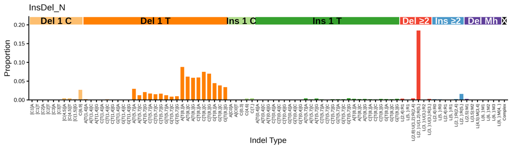

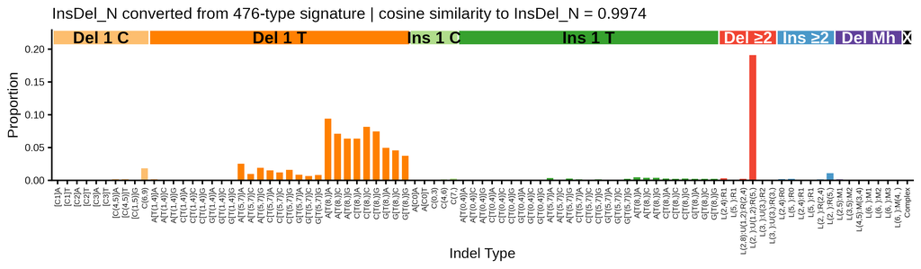

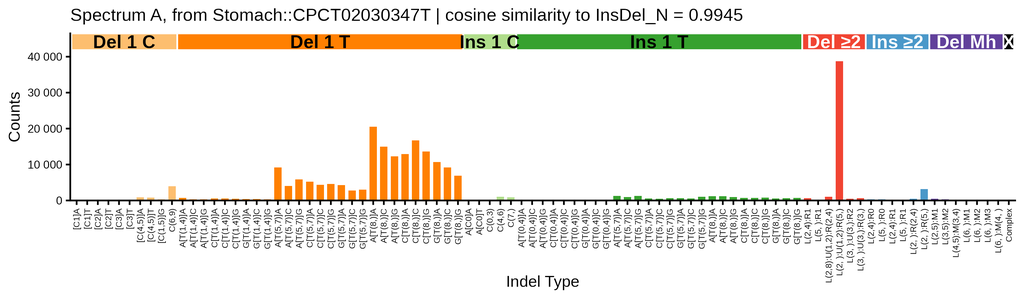

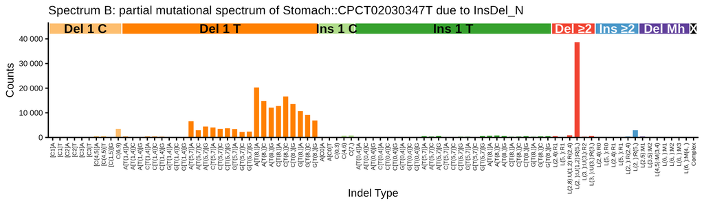

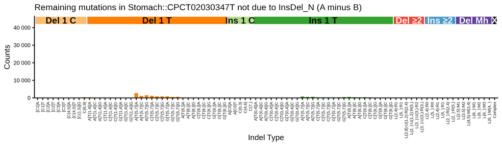

## 476-type representations corresponding to InsDel_N

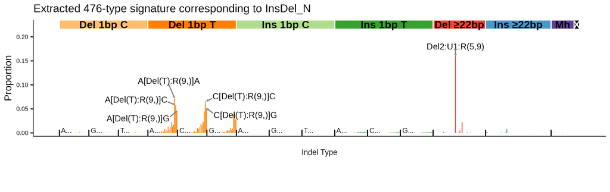

476-type spectrum of the supporting tumor Stomach::CPCT02030347T; cosine similarity to the extracted 476-type signature is 0.9767

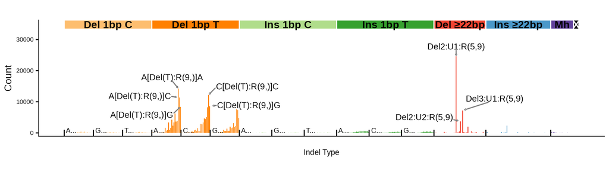

## 83-type signature corresponding to InsDel_N ( ID_N )

**Click here to show 83-type plots**

**Note**

WARNING: The 83-type ID_N extraction excluded the large proportion of T deletions in long poly-T contexts that were detected in extractions in the 89-type and 476-type classifications.

These single T deletions in long poly-T contexts are present in the 83-type signature collapsed from the 476-type InsDel_N signature, which makes the deletions of 2 bases hard to see in the plot.

However, since we are collapsing from 476-categories that does not capture the differences between InsDel_J (89-type representation of ID_J) and InsDel_N (89-type representation of ID_N)very well, the differences between InsDel_J and InsDel_N are not visible.

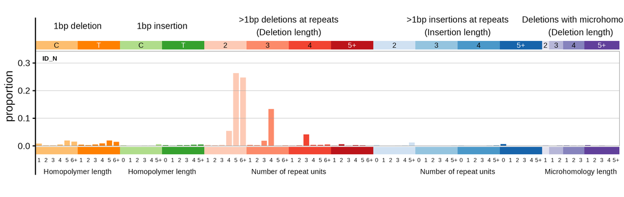

83-type signature converted from 476-type signature corresponding to InsDel_N | cosine similarity to ID_N: 0.04755

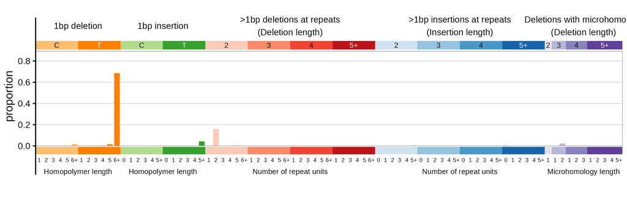

**Click here to see with insertions and deletions of T in long poly-T suppressed**

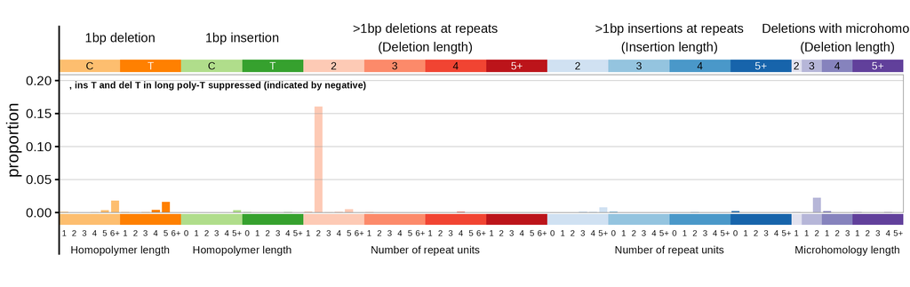

**Caution**

For the supporting tumor plot, mutation counts for insertions and deletions of T in long-poly-T contexts were set to 0. They were also set to 0 when calculating cosine similarity with the signature. The signature was not altered when computing the cosine similarity.

83-type spectrum of the supporting tumor Stomach::CPCT02030347T | cosine similarly to ID_N: 0.9237

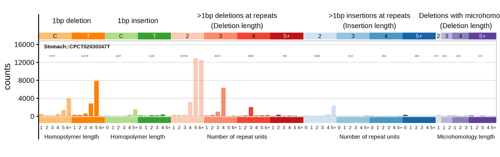